# Hong Kong Electricity Consumption Forecast 2020-2021

# 1. Introduction

Electricity is the most common energy source for homes and offices in Hong Kong. The electricity consumed in Hong Kong is generated mainly using coal, natural gas and nuclear energy as the sources. Electricity consumption forecast is one of the critical task for planning engineers in electric company, as the power generation planning and electricity dispatching bases on the consumption forecast.

This article is to analyse Hong Kong electricity time series data from 1970 to 2019 with time series analysis tools and do forecast for the future a few years. The data is downloaded from the official website of [Census and Statistics Department](https://www.censtatd.gov.hk/home/index.jsp) of Hong Kong.

# 2. Data Preparation

```r
# Load packages
library(tidyverse)
library(xts)
library(forecast)
library(tseries)
library(ggfortify)
```

```r
# read the data
df <- read.csv("hk_electricity.csv")

# inspect the first and last few rows
head(df)
```

|  | Year | Month | Domestic | Commercial | Industrial | Street.lighting | Exports.to.the.mainland.of.China | All.groups |
| --- | --- | --- | --- | --- | --- | --- | --- | --- |
| 1 | 1970 | Jan | 236 | 419 | 526 | 6 | 0 | 1186 |
| 2 | 1970 | Feb | 235 | 374 | 393 | 6 | 0 | 1008 |
| 3 | 1970 | Mar | 214 | 370 | 471 | 6 | 0 | 1061 |
| 4 | 1970 | Apr | 235 | 429 | 570 | 6 | 0 | 1240 |
| 5 | 1970 | May | 235 | 477 | 577 | 6 | 0 | 1295 |
| 6 | 1970 | Jun | 302 | 576 | 551 | 6 | 0 | 1435 |

```r
tail(df)
```

|  | Year | Month | Domestic | Commercial | Industrial | Street.lighting | Exports.to.the.mainland.of.China | All.groups |
| --- | --- | --- | --- | --- | --- | --- | --- | --- |
| 593 | 2019 | May | 3295 | 9660 | 962 | 29 | 0 | 13946 |
| 594 | 2019 | Jun | 4788 | 10308 | 1011 | 26 | 0 | 16133 |
| 595 | 2019 | Jul | 5239 | 11034 | 1033 | 32 | 0 | 17337 |
| 596 | 2019 | Aug | 5497 | 10497 | 1024 | 30 | 0 | 17048 |
| 597 | 2019 | Sep | 4879 | 9827 | 917 | 32 | 0 | 15656 |
| 598 | 2019 | Oct | 4016 | 9265 | 895 | 34 | 0 | 14209 |

It can be found that the Hong Kong electricity consumption data starts from Jan 1970 an ends in Oct 2019, showing the monthly electricity consumption data of different categories including domestic, commercial, industrial, street lighting and the exports to Mainland China.

This article will focus on forecasting domestic electricity consumption by Arima and ETS model. To test the accuracy of our models, we select the data before 2019 as training dataset, select data in 2019 as test dataset for comparison.

```r
# Count the number of rows
nrow(df)
```

```
[1] 598
```

```r
domestic_train <- head(df$Domestic, nrow(df) - 10)
domestic_test <- tail(df$Domestic, 10)
```

```r
# change training data to time series format
ts_domestic <- ts(df$Domestic, frequency = 12, start = c(1970, 1), end = c(2019, 10))
ts_domestic_train <- ts(domestic_train, frequency = 12, start = c(1970, 1), end = c(2018, 12))
ts_domestic_test <- ts(domestic_test, frequency = 12, start = c(2019, 1))
```

# Data Understanding and Visualization

```r
# Check how many observations there are for each unit of time
frequency(ts_domestic_train)
```

```
[1] 12
```

```r
summary(ts_domestic_train)
```

```
   Min. 1st Qu.  Median    Mean 3rd Qu.    Max.
    214     750    1746    1970    2755    5932
```

Let’s plot the domestic electricity consumption data to understand it better.

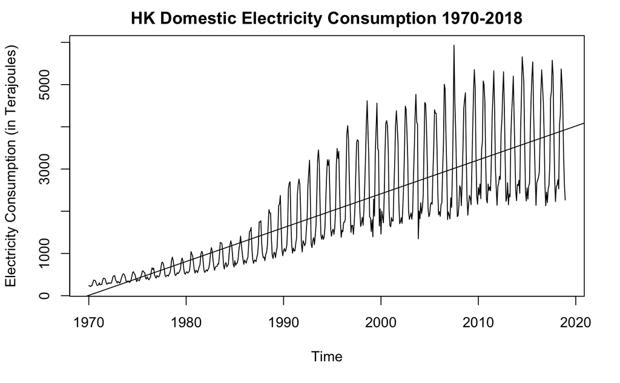

```r
# Plot the training set and add a linear regression line
plot(ts_domestic_train, ylab = "Electricity Consumption (in Terajoules)", main = "HK Domestic Electricity Consumption 1970-2018")
abline(reg=lm(ts_domestic_train~time(ts_domestic_train)))
```

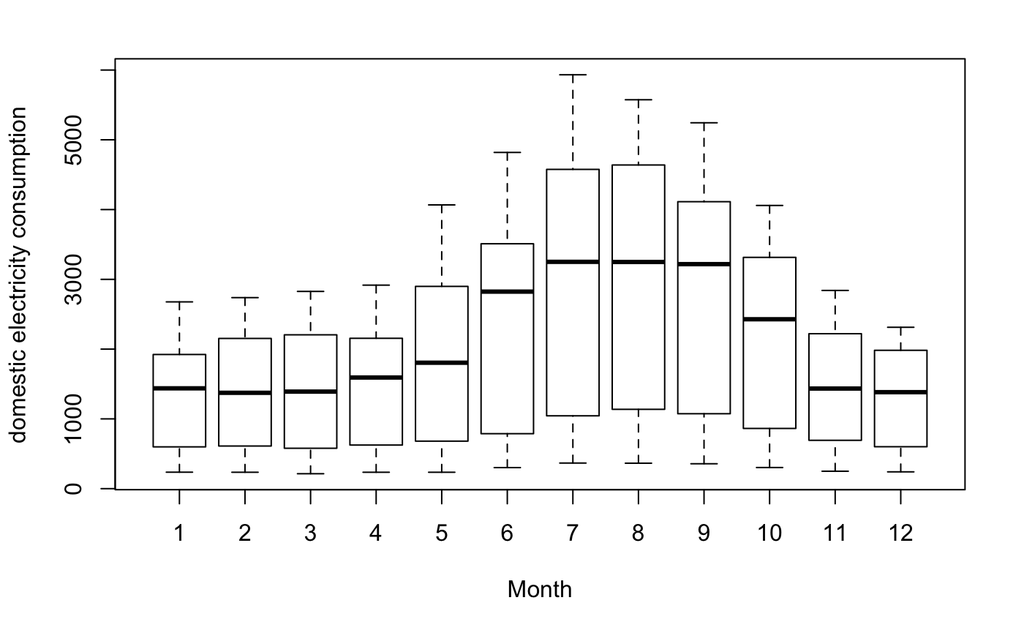

```r
boxplot(ts_domestic_train~cycle(ts_domestic_train), xlab = "Month", ylab = "domestic electricity consumption")
```

# 3. Decomposition

After data visualization, we can see that there is a general trend upwards of domestic electricity consumption since 1970. Besides, it is obvious that there is a pretty consistent seasonal pattern, with peak electricity consumption happening every year in the summer months and with off peak times in winter months.

Now we can decompose our data and separate this general trend from the seasonal trend.

```
attributes are not identical across measure variables;
they will be dropped
```

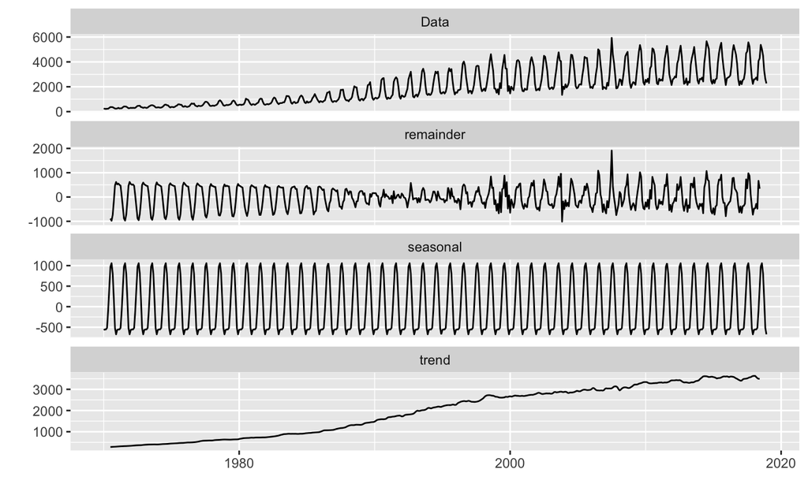

```r
decomposed <- decompose(ts_domestic_train)
autoplot(decomposed)
```

# 4. Time Series Analysis and Forecast

## 4.1 ARIMA model

Auto ARIMA makes time series analysis really simple for us as it eliminates steps such as making data stationary, determining pdq values. Below are the steps for implementing auto ARIMA:

1. Load the data: This step will be the same. Load the data into your notebook
2. Preprocessing data: The input should be univariate, hence drop the other columns
3. Fit Auto ARIMA: Fit the model on the univariate series
4. Predict values on validation set: Make predictions on the validation set
5. Calculate RMSE: Check the performance of the model using the predicted values against the actual values

```r
arima <- auto.arima(ts_domestic_train)
arima
```

```
Series: ts_domestic_train
ARIMA(2,0,1)(0,1,2)[12] with drift

Coefficients:
          ar1     ar2     ma1     sma1    sma2   drift
      -0.3817  0.3449  0.6341  -0.6521  0.1373  5.7546
s.e.   0.0955  0.0421  0.0947   0.0476  0.0475  0.5626

sigma^2 estimated as 43837:  log likelihood=-3895.19
AIC=7804.37   AICc=7804.57   BIC=7834.86
```

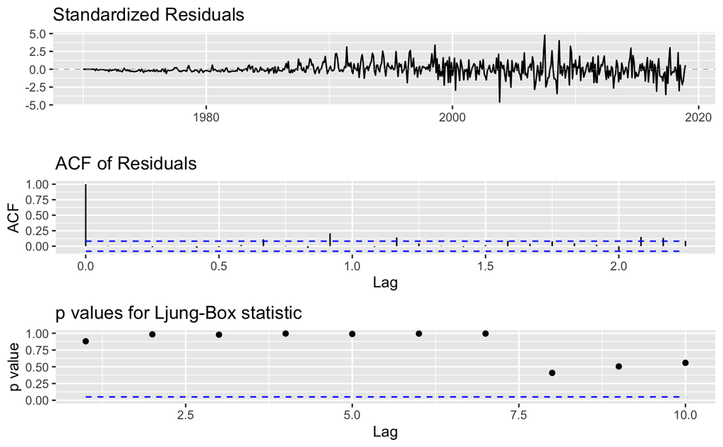

```r
#T he ggtsdiag function from ggfortify R package performs model diagnostics of the residuals and the acf. will include a autocovariance plot.
ggtsdiag(arima)
```

The residual plots appear to be centered around 0 as noise, with no pattern. the arima model is a good fit.

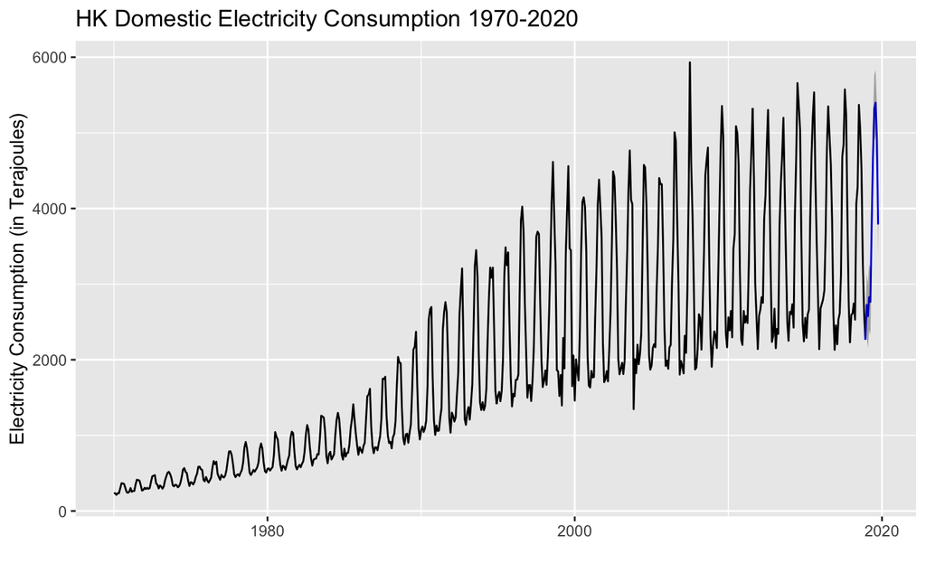

```r
# We can plot a forecast of the time series using the arima model, with a 95% confidence interval, forecasted data till Oct 2019.
arima_forecast <- forecast(arima, h=10, level = c(95)) # 10 for 2019.01-2019.10

autoplot(arima_forecast, main = ("HK Domestic Electricity Consumption 1970-2020")) + ylab("Electricity Consumption (in Terajoules)")
```

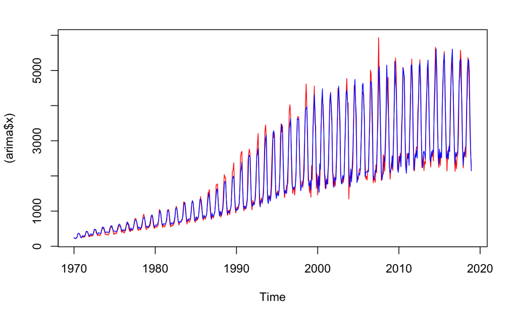

```r
# visualize the model overall accuracy
plot((arima$x), col = "red")
lines((arima$fitted), col = "blue")
```

## 4.2 ETS Model

Exponential Smoothing Methods are a family of forecasting models. They use weighted averages of past observations to forecast new values. Here, the idea is to give more importance to recent values in the series. Thus, as observations get older (in time), the importance of these values get exponentially smaller. Exponential Smoothing Methods combine Error, Trend, and Seasonal components in a smoothing calculation. Each term can be combined either additively, multiplicatively, or be left out of the model. These three terms (**E**rror, **T**rend, and **S**eason) are referred to as **ETS**.

You can find more information about ETS model [here](https://medium.com/better-programming/exponential-smoothing-methods-for-time-series-forecasting-d571005cdf80).

Now let’s built the ETS model for our data.

```r
# Automated forecasting using an ETS model
ets <- ets(ts_domestic_train)
ets
```

```
ETS(M,A,M)

Call:
 ets(y = ts_domestic_train)

  Smoothing parameters:
    alpha = 0.0547
    beta  = 0.0024
    gamma = 0.3311

  Initial states:
    l = 276.6521
    b = 3.1489
    s = 0.8044 0.8538 1.0496 1.2502 1.2938 1.3168
           1.1035 0.8987 0.8411 0.8177 0.8941 0.8762

  sigma:  0.0823

     AIC     AICc      BIC
9400.179 9401.253 9474.583
```

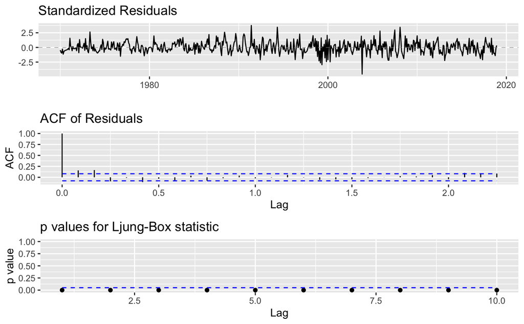

```r
# The ggtsdiag function from ggfortify R package performs model diagnostics of the residuals and the acf. will include a autocovariance plot.
ggtsdiag(ets)
```

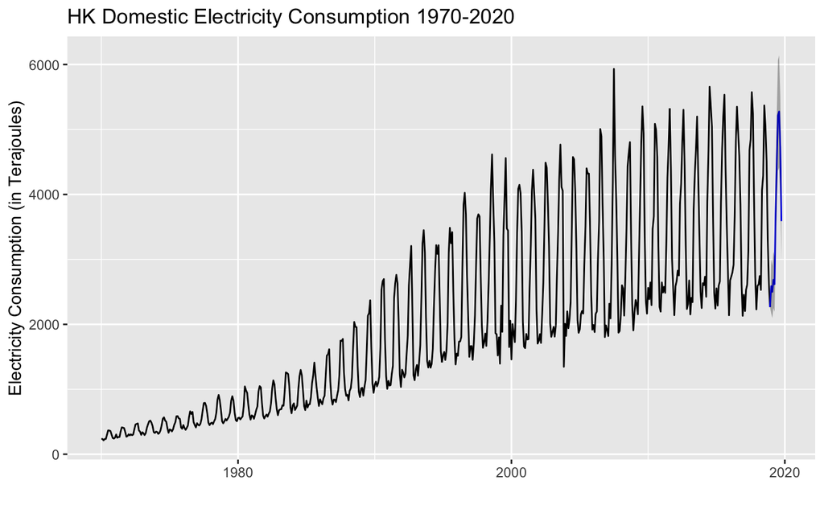

```r
# We can plot a forecast of the time series using the ETS model, with a 95% confidence interval, forecasted data till Oct 2019
ets_forecast <- forecast(ets, h=10, level = c(95)) # 10 for 2019.01-2019.10

autoplot(ets_forecast, main = ("HK Domestic Electricity Consumption 1970-2020")) + ylab("Electricity Consumption (in Terajoules)")
```

## 4.3 Model Comparison

We can compare the two models results to find which one is more accurate for our data.

```r
ts.union(ts_domestic_test, head(arima_forecast$mean,10), head(ets_forecast$mean,10))
```

```
         ts_domestic_test head(arima_forecast$mean, 10) head(ets_forecast$mean, 10)
Jan 2019             2472                      2726.672                    2587.353
Feb 2019             2271                      2575.817                    2499.798
Mar 2019             2551                      2827.747                    2685.205
Apr 2019             2862                      2764.951                    2617.985
May 2019             3295                      3787.751                    3726.312
Jun 2019             4788                      4703.712                    4529.408
Jul 2019             5239                      5319.727                    5214.589
Aug 2019             5497                      5398.321                    5275.998
Sep 2019             4879                      4943.719                    4736.533
Oct 2019             4016                      3788.269                    3588.955
```

```r
# Plot the comparison
plot(ts_domestic_test, ylab = "Domestic Electricity Consumption")
lines(head(arima_forecast$mean,10), col="blue")
```

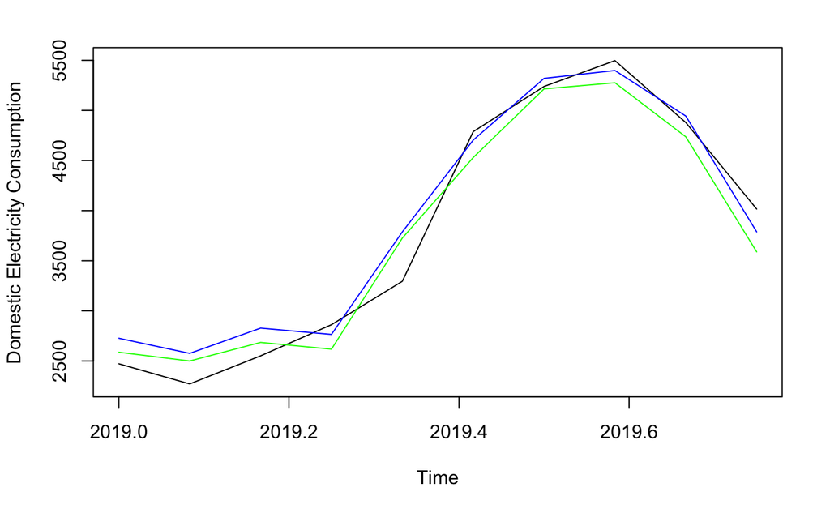

```r
lines(head(ets_forecast$mean,10), col="green")
```

It is difficult to decide which one is better. Let’s explore more about the accuracy indicators for training set and test set.

```r
arima_forecast %>% forecast(h = 10) %>%
  accuracy(ts_domestic)
```

```
                      ME     RMSE      MAE       MPE     MAPE      MASE         ACF1
Training set  -0.4042522 206.1425 136.5348 -2.043413 7.291473 0.7858197  0.006191768
Test set     -96.6685577 237.9057 198.2180 -3.977775 6.501196 1.1408347 -0.191116173
             Theil's U
Training set        NA
Test set     0.4497766
```

```r
ets_forecast %>% forecast(h = 10) %>%
  accuracy(ts_domestic)
```

```
                    ME     RMSE      MAE        MPE     MAPE      MASE       ACF1 Theil's U
Training set -4.335815 207.0224 134.2488 -0.4650076 6.311467 0.7726629  0.1481814        NA
Test set     40.786370 254.5998 222.7200 -0.1125124 6.505875 1.2818547 -0.1488072 0.4337297
```

Therefore, we generate and plot forecasts from ARIMA model for the next 2 years.

# 5. Forecast with ARIMA Model

## 5.1 Forecast Domestic Electricity Consumption

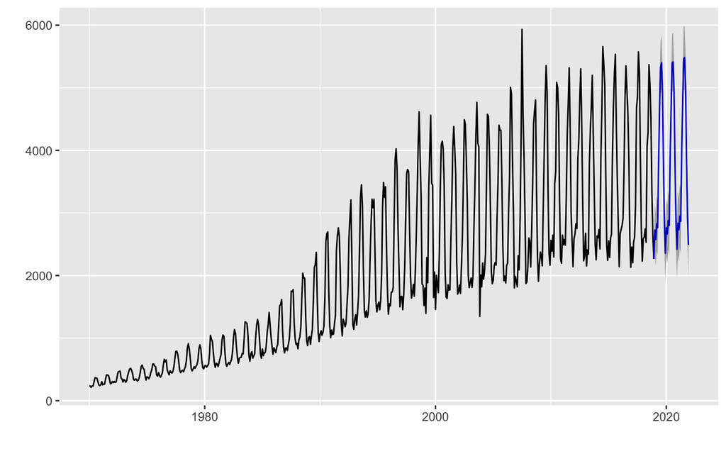

```r
forecast_2021 <- forecast(arima, h=10+2+24, level = c(95))
autoplot(forecast_2021)
```

```r
forecast_2021$mean
```

```
          Jan      Feb      Mar      Apr      May      Jun      Jul      Aug      Sep
2019 2726.672 2575.817 2827.747 2764.951 3787.751 4703.712 5319.727 5398.321 4943.719
2020 2763.396 2665.850 2877.682 2799.576 3901.373 4699.561 5393.493 5413.801 4949.223
2021 2834.740 2732.059 2948.613 2866.933 3971.723 4767.536 5463.407 5482.156 5018.841
          Oct      Nov      Dec
2019 3788.269 2821.475 2356.697
2020 3776.513 2860.715 2420.031
2021 3845.111 2930.139 2488.788
```

## 5.2 Forecast Commerical Electricity Consumption

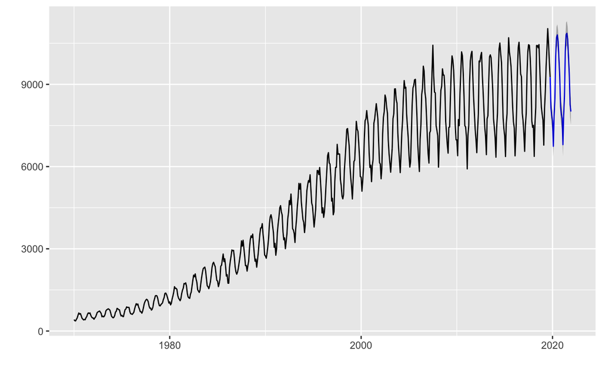

```r
# create commercial electricity tim-series data
ts_commercial <- ts(df$Commercial, frequency = 12, start = c(1970, 1), end = c(2019, 10))

# use auto arima model to forecast the data till the end of 2021
arima_commercial <- auto.arima(ts_commercial)

forecast_2021_commercial <- forecast(arima_commercial, h=2+24, level = c(95))

# plot the data
autoplot(forecast_2021_commercial)
```

```r
# check the forecast value of commercial electricity consumption
forecast_2021_commercial$mean
```

```
           Jan       Feb       Mar       Apr       May       Jun       Jul       Aug
2019
2020  7670.712  6740.099  7848.693  8484.819 10044.251 10708.693 10802.593 10569.845
2021  7762.687  6800.426  7885.582  8568.398 10177.897 10810.178 10861.603 10647.660
           Sep       Oct       Nov       Dec
2019                      8135.201  7862.877
2020  9933.874  9304.881  8196.556  7922.915
2021 10006.738  9386.979  8268.410  8008.904
```

## 5.3 Forecast Industrial Electricity Consumption

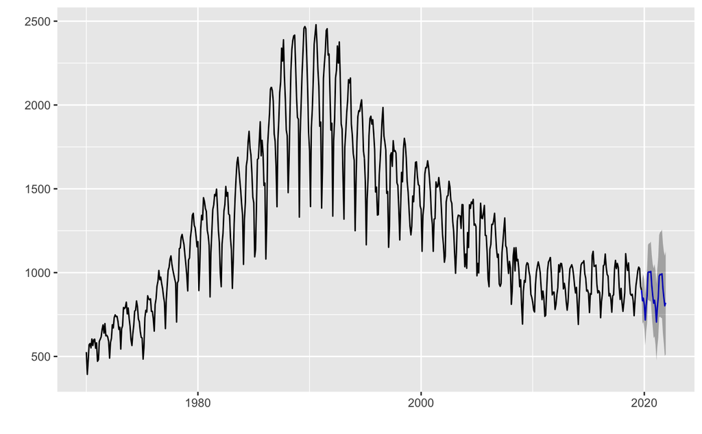

```r
# create commercial electricity tim-series data
ts_industrial <- ts(df$Industrial, frequency = 12, start = c(1970, 1), end = c(2019, 10))

# use auto arima model to forecast the data till the end of 2021
arima_industrial <- auto.arima(ts_industrial)

forecast_2021_industrial <- forecast(arima_industrial, h=2+24, level = c(95))

# plot the data
autoplot(forecast_2021_industrial)
```

We can find that the industrial electricity consumption data has seasonality as well, but the trend of it doesn’t like commercial and domestic data. The peak is around 1990 then the industrial data starts to drop. For the forecasted data, its 95% condidence interval range is much bigger than the forecast commeicial and domestic data.

```r
# check the forecast value of industrial electricity consumption
forecast_2021_industrial$mean
```

```
           Jan       Feb       Mar       Apr       May       Jun       Jul       Aug
2019
2020  808.0068  717.3663  803.8371  861.0334 1000.6446 1005.2573 1001.9197 1007.4896
2021  792.1385  704.9317  788.2821  852.1556  978.8942  989.6049  987.6600  993.1739
           Sep       Oct       Nov       Dec
2019                      832.3205  847.6440
2020  924.5390  865.4599  817.5544  835.3146
2021  905.6938  851.9187  802.0506  819.9885
```

## 5.4 Forecast Street Light Electricity Consumption

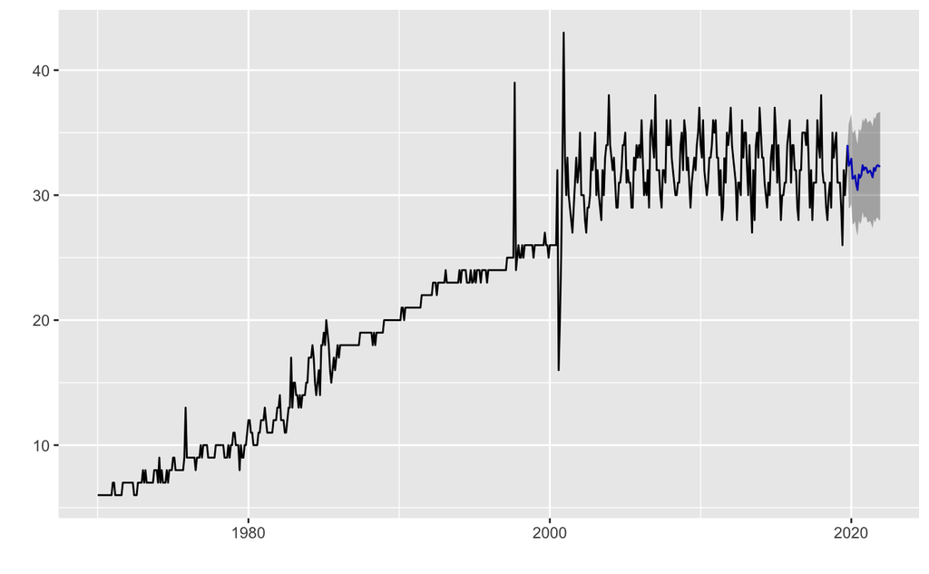

```r
# create commercial electricity tim-series data
ts_streetlight <- ts(df$Street.lighting, frequency = 12, start = c(1970, 1), end = c(2019, 10))

# use auto arima model to forecast the data till the end of 2021
arima_streetlight <- auto.arima(ts_streetlight)

forecast_2021_streetlight <- forecast(arima_streetlight, h=2+24, level = c(95))

# plot the data
autoplot(forecast_2021_streetlight)
```

It can be found that the time series model is not suitable for street light data as the original data doesn’t show consistent seasonality and trend. Besides, as the street light electricity consumption is much lower than other sectors, we won’t count it in the total consumption forecast.

## 5.5 Plot Forecast Data for 2020-2021

So we export the forecast data of 2020 and 2021 for domestic, commercial and industrial sectors.

```r
write.csv(forecast_2021$mean, "domestic.csv")
write.csv(forecast_2021_commercial$mean, "commercial.csv")
write.csv(forecast_2021_industrial$mean, "industrial.csv")
```

After data merging and cleaning in excel, we use **Tableau** to make area plot to show the forecasted electricity consumption by sectors in 2020-2021.

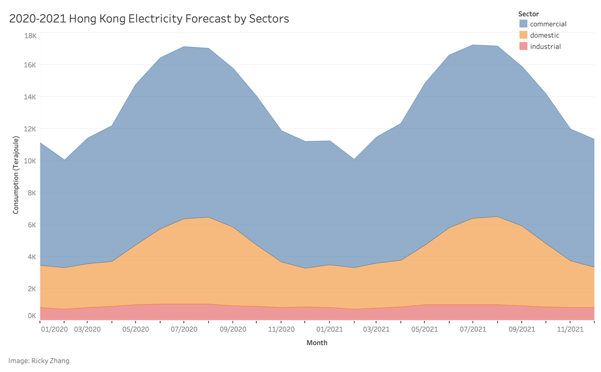

We can see all three sectors shows seasonality characteristics with peaks in summer and valleys in winter times, but the industrial data is relatively stable. The peak of total consumption appears in July and August, around 17000 terajoule, the valley of total consumption appears in February, around 10000 terajoule.

# 6. Conclusion

The forecast and estimation data can be helpful for power untility companies like CLP to better plan our electric power generation and power station outage works.